# RNA-Seq Differential Expression: Dexamethasone in Airway Smooth Muscle Cells

Adnan Warsi

2026-10-29

```r
library(DESeq2)
library(airway)
library(org.Hs.eg.db)
library(topGO)
library(ggplot2)
library(ggrepel)
library(pheatmap)
library(dplyr)
dir.create("results", showWarnings = FALSE)
set.seed(42)
```

# 1. Aim and dataset

**Aim:** find genes whose expression changes when human airway smooth muscle cells are treated with dexamethasone (a glucocorticoid drug), and describe the biological processes involved.

**Data:** public dataset GSE52778 (Himes et al., 2014). Cells from 4 donors, each either untreated or treated with 1 uM dexamethasone for 18 hours (8 samples in total). Gene-level read counts come from the Bioconductor `airway` package.

```r
data(airway)
dds <- DESeqDataSet(airway, design = ~ cell + dex)
dds$dex <- relevel(dds$dex, ref = "untrt")
as.data.frame(colData(dds))[, c("SampleName", "cell", "dex", "Run")]
```

```
##            SampleName    cell   dex        Run
## SRR1039508 GSM1275862  N61311 untrt SRR1039508
## SRR1039509 GSM1275863  N61311   trt SRR1039509
## SRR1039512 GSM1275866 N052611 untrt SRR1039512
## SRR1039513 GSM1275867 N052611   trt SRR1039513
## SRR1039516 GSM1275870 N080611 untrt SRR1039516
## SRR1039517 GSM1275871 N080611   trt SRR1039517
## SRR1039520 GSM1275874 N061011 untrt SRR1039520
## SRR1039521 GSM1275875 N061011   trt SRR1039521
```

# 2. Quality control (FastQC)

FastQC was run on the first 100,000 reads (read 1) of one untreated sample (SRR1039508) and one treated sample (SRR1039509). Reports are in `results/fastqc/`.

**Observations (from the FastQC summary of both samples):**

- Both samples passed 10 of the 11 FastQC modules, including per base sequence quality, per sequence quality scores, per base N content, per sequence GC content, sequence duplication levels and adapter content.
- No adapter contamination was detected, so adapter trimming was not required.
- Both samples raised a warning for “Overrepresented sequences”. In RNA-Seq this can happen when a few highly expressed transcripts account for a large share of reads. These sequences were not investigated further here.
- The two samples gave the same pattern of results, so neither looked like an outlier on read quality.

Note: FastQC was run on a subset of reads from two samples to demonstrate the QC step. The differential expression analysis below uses the full gene-level count matrix from the `airway` package.

# 3. Filtering and normalisation

Genes with fewer than 10 reads in at least 4 samples were removed because low-count genes carry little statistical information. DESeq2 normalises library size with the median-of-ratios method, and a variance stabilising transformation (VST) is used for plots.

```r
cat("Genes before filtering:", nrow(dds), "\n")
```

```
## Genes before filtering: 63677
```

```r
dds <- dds[rowSums(counts(dds) >= 10) >= 4, ]
cat("Genes after filtering:", nrow(dds), "\n")
```

```
## Genes after filtering: 16139
```

# 4. Differential expression (DESeq2)

Model: `~ cell + dex`, so the donor (cell line) effect is accounted for. Contrast: treated vs untreated. A gene is called differentially expressed if adjusted p < 0.05 and |log2 fold change| >= 1.

```r
dds <- DESeq(dds)
res <- results(dds, contrast = c("dex", "trt", "untrt"), alpha = 0.05)
summary(res)
```

```
##
## out of 16139 with nonzero total read count
## adjusted p-value < 0.05
## LFC > 0 (up)       : 2190, 14%
## LFC < 0 (down)     : 1891, 12%
## outliers [1]       : 0, 0%
## low counts [2]     : 313, 1.9%
## (mean count < 10)
## [1] see 'cooksCutoff' argument of ?results
## [2] see 'independentFiltering' argument of ?results
```

```r
res_df <- as.data.frame(res)
res_df$ensembl <- rownames(res_df)
res_df$symbol <- unname(mapIds(org.Hs.eg.db, keys = res_df$ensembl,
                               column = "SYMBOL", keytype = "ENSEMBL",
                               multiVals = "first"))
res_df <- res_df %>%
  filter(!is.na(padj)) %>%
  mutate(status = case_when(
    padj < 0.05 & log2FoldChange >= 1  ~ "Up",
    padj < 0.05 & log2FoldChange <= -1 ~ "Down",
    TRUE ~ "NS"))
write.csv(res_df, "results/DE_results.csv", row.names = FALSE)
table(res_df$status)
```

```
##
##  Down    NS    Up
##   461 14875   490
```

# 5. Sample relationships (PCA)

```
## using ntop=500 top features by variance
```

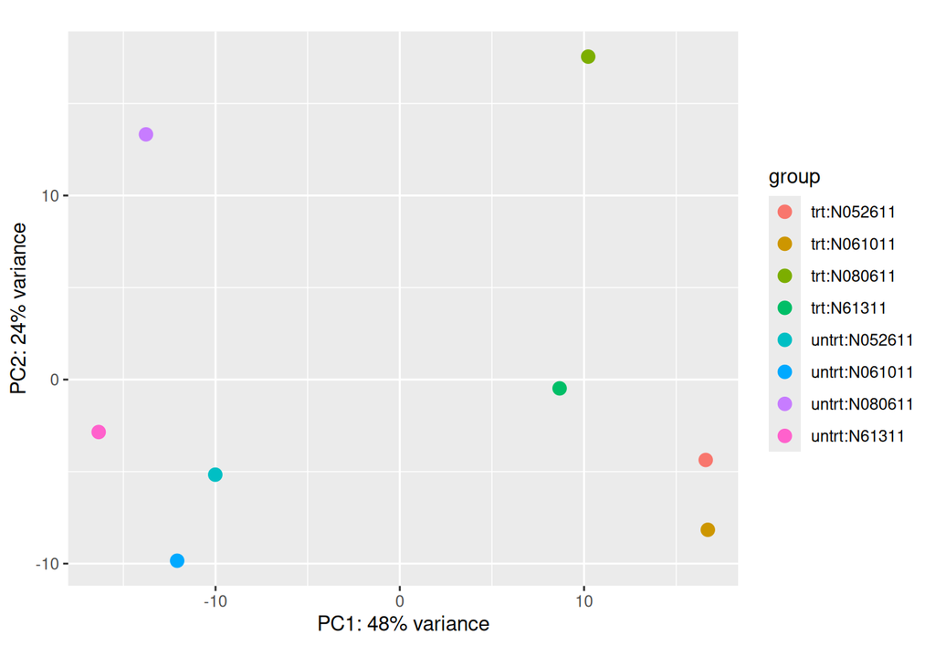

```r
vsd <- vst(dds, blind = FALSE)
plotPCA(vsd, intgroup = c("dex", "cell"))
```

Samples separate by treatment and by donor, which is why `cell` is included in the model.

# 6. Volcano plot

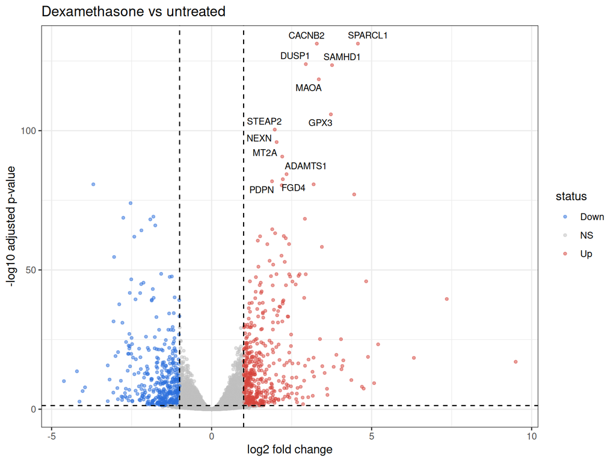

```r
lab <- res_df %>%
  filter(status != "NS", !is.na(symbol)) %>%
  arrange(padj) %>%
  head(12)

ggplot(res_df, aes(log2FoldChange, -log10(padj), colour = status)) +
  geom_point(alpha = 0.5, size = 1) +
  scale_colour_manual(values = c(Down = "#2a6fdb", NS = "grey75", Up = "#d6453d")) +
  geom_vline(xintercept = c(-1, 1), linetype = "dashed") +
  geom_hline(yintercept = -log10(0.05), linetype = "dashed") +
  geom_text_repel(data = lab, aes(label = symbol), colour = "black",
                  size = 3, max.overlaps = 20) +
  theme_bw() +
  labs(title = "Dexamethasone vs untreated",
       x = "log2 fold change", y = "-log10 adjusted p-value")
```

# 7. Heatmap of top differentially expressed genes

The 30 most significant genes (by adjusted p-value), shown as row-scaled VST expression.

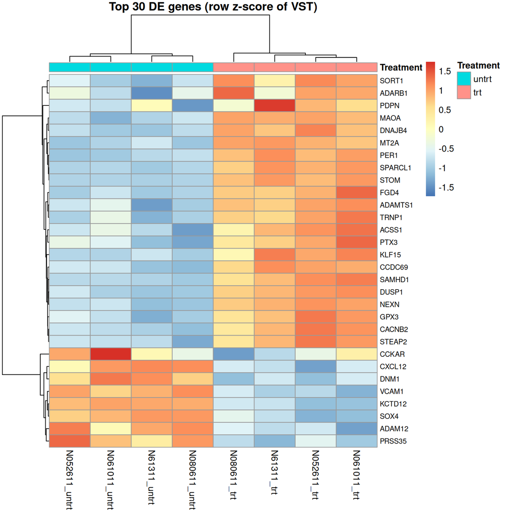

```r
top <- res_df %>%
  filter(status != "NS", !is.na(symbol)) %>%
  arrange(padj) %>%
  head(30)

mat <- assay(vsd)[top$ensembl, ]
rownames(mat) <- top$symbol
colnames(mat) <- paste0(vsd$cell, "_", vsd$dex)
ann <- data.frame(Treatment = vsd$dex, row.names = colnames(mat))

pheatmap(mat, scale = "row", annotation_col = ann,
         clustering_method = "ward.D2", fontsize_row = 8,
         main = "Top 30 DE genes (row z-score of VST)")
```

# 8. Top up- and down-regulated genes

```r
cat("Top 10 up-regulated genes\n")
```

```
## Top 10 up-regulated genes
```

```r
res_df %>% filter(status == "Up") %>% arrange(desc(log2FoldChange)) %>%
  select(symbol, log2FoldChange, padj) %>% head(10)
```

```
##                  symbol log2FoldChange          padj
## ENSG00000179593 ALOX15B       9.501984  9.376550e-18
## ENSG00000109906  ZBTB16       7.348689  2.724385e-40
## ENSG00000250978    <NA>       6.320704  3.695728e-19
## ENSG00000127954  STEAP4       5.203142  5.198273e-24
## ENSG00000171819 ANGPTL7       5.077816  4.475773e-10
## ENSG00000100033   PRODH       4.886672  1.653117e-19
## ENSG00000168309 FAM107A       4.828810  1.223317e-46
## ENSG00000168481    LGI3       4.751445  3.931188e-08
## ENSG00000128045 RASL11B       4.698420  8.322884e-09
## ENSG00000152583 SPARCL1       4.570944 5.641706e-132
```

```r
cat("Top 10 down-regulated genes\n")
```

```
## Top 10 down-regulated genes
```

```r
res_df %>% filter(status == "Down") %>% arrange(log2FoldChange) %>%
  select(symbol, log2FoldChange, padj) %>% head(10)
```

```
##                    symbol log2FoldChange         padj
## ENSG00000267339 LINC00906      -4.615078 8.147398e-11
## ENSG00000146006    LRRTM2      -4.208406 2.454549e-14
## ENSG00000141469   SLC14A1      -4.129282 1.807430e-03
## ENSG00000155897     ADCY8      -4.030558 3.093229e-07
## ENSG00000143494     VASH2      -3.955635 1.415070e-08
## ENSG00000162692     VCAM1      -3.696265 1.864957e-81
## ENSG00000188176    SMTNL2      -3.245213 1.881156e-16
## ENSG00000108688      CCL7      -3.244675 1.316432e-03
## ENSG00000184564   SLITRK6      -3.188372 2.283651e-11
## ENSG00000122877      EGR2      -3.070740 1.104450e-06
```

# 9. Gene Ontology (GO) enrichment

GO “Biological Process” enrichment was done with topGO (Fisher’s exact test, `weight01` algorithm). The background (universe) is all genes that passed filtering and were tested, and the test set is all DE genes (up and down).

```r
all_genes <- res_df$ensembl
de_genes <- res_df$ensembl[res_df$status != "NS"]
gene_list <- factor(as.integer(all_genes %in% de_genes))
names(gene_list) <- all_genes

go_data <- new("topGOdata",
               ontology = "BP",
               allGenes = gene_list,
               annot = annFUN.org,
               mapping = "org.Hs.eg.db",
               ID = "ensembl",
               nodeSize = 10)

go_test <- runTest(go_data, algorithm = "weight01", statistic = "fisher")
go_tab <- GenTable(go_data, Fisher = go_test, orderBy = "Fisher",
                   topNodes = 15, numChar = 70)
go_tab$Fisher <- as.numeric(go_tab$Fisher)
write.csv(go_tab, "results/GO_BP_enrichment.csv", row.names = FALSE)
go_tab
```

```
##         GO.ID                                                             Term
## 1  GO:0001525                                                     angiogenesis
## 2  GO:0042572                                        retinol metabolic process
## 3  GO:0007411                                                    axon guidance
## 4  GO:0030198                                extracellular matrix organization
## 5  GO:0045776                            negative regulation of blood pressure
## 6  GO:0021602                                      cranial nerve morphogenesis
## 7  GO:0007169 transmembrane receptor protein tyrosine kinase signaling pathway
## 8  GO:0048640                      negative regulation of developmental growth
## 9  GO:0042573                                  retinoic acid metabolic process
## 10 GO:0006955                                                  immune response
## 11 GO:0009410                                  response to xenobiotic stimulus
## 12 GO:0034765             regulation of monoatomic ion transmembrane transport
## 13 GO:0016331                            morphogenesis of embryonic epithelium
## 14 GO:0007263                        nitric oxide mediated signal transduction
```

[output cut: 17 more lines]

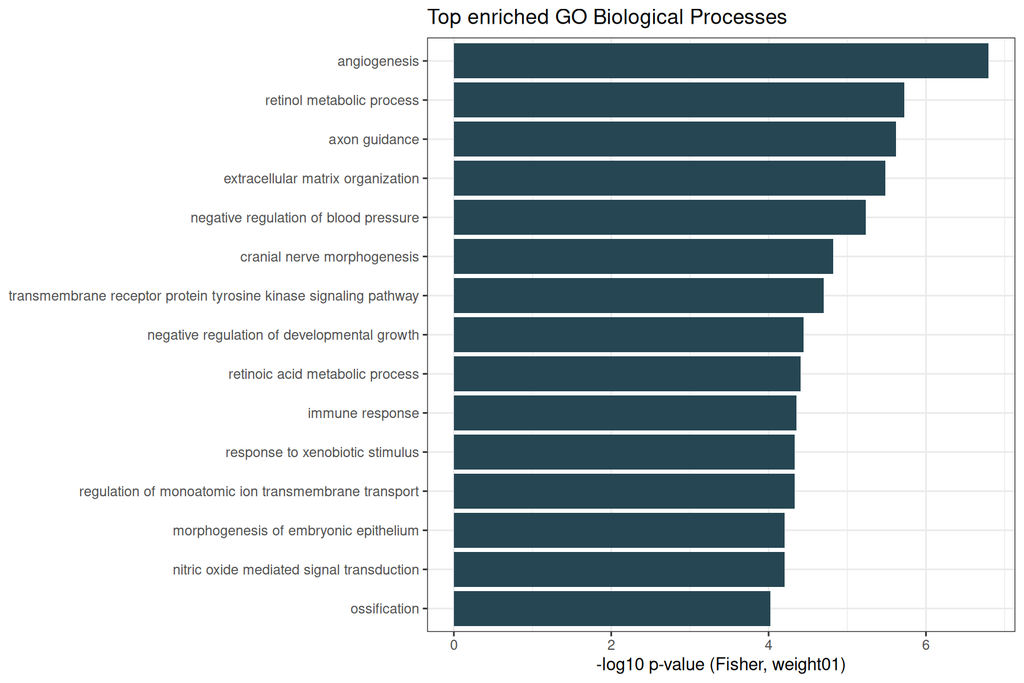

```r
go_tab$Term <- factor(go_tab$Term, levels = rev(go_tab$Term))
ggplot(go_tab, aes(Term, -log10(Fisher))) +
  geom_col(fill = "#264653") +
  coord_flip() +
  theme_bw() +
  labs(title = "Top enriched GO Biological Processes",
       x = NULL, y = "-log10 p-value (Fisher, weight01)")
```

# 10. Interpretation

**How many genes changed?** Of 15,826 genes tested after filtering, 951 were differentially expressed (adjusted p < 0.05 and |log2 fold change| >= 1): 490 were up-regulated and 461 were down-regulated by dexamethasone.

**Which genes stand out?** The most strongly induced genes included ALOX15B, ZBTB16, STEAP4, ANGPTL7 and FAM107A. ZBTB16 and FAM107A have been reported as glucocorticoid-responsive, which supports that the treatment effect was captured. Among down-regulated genes, VCAM1 was the most statistically significant (adjusted p about 1.9e-81), and the chemokine CCL7 was also reduced. Both are linked to inflammation, which fits the anti-inflammatory action of glucocorticoids. The top-up and top-down lists are ranked by fold change, whereas the heatmap shows the most significant genes.

**What do the GO terms say?** The top enriched Biological Process terms included angiogenesis, extracellular matrix organisation, retinol and retinoic acid metabolic processes, and immune response. This suggests that dexamethasone affects tissue remodelling and inflammatory signalling in airway smooth muscle cells. Some top terms (for example axon guidance and cranial nerve morphogenesis) are broad developmental terms that often arise from shared signalling and matrix genes, so they should be interpreted cautiously.

**Limitations.** Only 4 donors and one cell type were used. Gene-level counts came from the `airway` package and were not re-aligned from raw reads. GO p-values are not corrected for multiple testing, and enrichment shows association, not causation. FastQC was run on a subset of reads from two samples only.

# 11. Reproducibility

Run `rmarkdown::render("Task2_RNAseq_DESeq2.Rmd")` from the project folder. Required R packages: DESeq2, airway, org.Hs.eg.db, topGO, GO.db, ggplot2, ggrepel, pheatmap, dplyr, rmarkdown.